# CS 422 HW3

Matthew Venter

### Loading librarys

```r
library(dplyr)
library(plyr)
library(arules)
library(arulesViz)
library(cluster)
library(factoextra)
library(fpc)
```

### Part 2.1-a Creating data frames needed

```r
#creating regular dataframes
tr1k.df<- read.transactions(file ="Tr_1k_can.csv", sep=",", header=F)
tr5k.df<- read.transactions(file ="tr-5k-can.csv", sep=",", header=F)
tr20k.df<- read.transactions(file ="tr-20k-can.csv", sep=",", header=F)
tr75k.df<- read.transactions(file ="tr-75k-can.csv", sep=",", header=F)
```

### Part 2.1-b Evaluating rules

```r
#tr1k inspection
inspect(sort(tr1k.freq, decreasing = T, by="count"))
```

|  | items | support | count |
| --- | --- | --- | --- |
| [1] | {Gongolais Cookie} | 0.108 | 108 |
| [2] | {Truffle Cake} | 0.103 | 103 |
| [3] | {Tuile Cookie} | 0.102 | 102 |
| [4] | {Berry Tart} | 0.095 | 95 |
| [5] | {Coffee Eclair} | 0.093 | 93 |
| [6] | {Strawberry Cake} | 0.091 | 91 |
| [7] | {Marzipan Cookie} | 0.090 | 90 |
| [8] | {Napoleon Cake} | 0.090 | 90 |
| [9] | {Apple Croissant} | 0.090 | 90 |
| [10] | {Hot Coffee} | 0.087 | 87 |

[output cut: 35 more lines]

```r
inspect(sort(tr1k.rules, decreasing = T, by="count"))
```

|  | lhs |  | rhs | support | confidence | lift | count |
| --- | --- | --- | --- | --- | --- | --- | --- |
| [1] | {} | => | {Gongolais Cookie} | 0.108 | 0.1080000 | 1.000000 | 108 |
| [2] | {} | => | {Truffle Cake} | 0.103 | 0.1030000 | 1.000000 | 103 |
| [3] | {} | => | {Tuile Cookie} | 0.102 | 0.1020000 | 1.000000 | 102 |
| [4] | {Truffle Cake} | => | {Gongolais Cookie} | 0.058 | 0.5631068 | 5.213952 | 58 |
| [5] | {Gongolais Cookie} | => | {Truffle Cake} | 0.058 | 0.5370370 | 5.213952 | 58 |
| [6] | {Marzipan Cookie} | => | {Tuile Cookie} | 0.053 | 0.5888889 | 5.773420 | 53 |
| [7] | {Tuile Cookie} | => | {Marzipan Cookie} | 0.053 | 0.5196078 | 5.773420 | 53 |
| [8] | {Strawberry Cake} | => | {Napoleon Cake} | 0.049 | 0.5384615 | 5.982906 | 49 |
| [9] | {Napoleon Cake} | => | {Strawberry Cake} | 0.049 | 0.5444444 | 5.982906 | 49 |

```r
#tr5k inspection
inspect(sort(tr5k.freq, decreasing = T, by="count"))
```

|  | items | support | count |
| --- | --- | --- | --- |
| [1] | {Coffee Eclair} | 0.1108 | 554 |
| [2] | {Hot Coffee} | 0.0998 | 499 |
| [3] | {Tuile Cookie} | 0.0996 | 498 |
| [4] | {Strawberry Cake} | 0.0960 | 480 |
| [5] | {Gongolais Cookie} | 0.0954 | 477 |
| [6] | {Cherry Tart} | 0.0920 | 460 |
| [7] | {Orange Juice} | 0.0912 | 456 |
| [8] | {Apricot Danish} | 0.0890 | 445 |
| [9] | {Truffle Cake} | 0.0876 | 438 |
| [10] | {Blueberry Tart} | 0.0852 | 426 |

[output cut: 33 more lines]

```r
inspect(sort(tr5k.rules, decreasing = T, by="count"))
```

|  | lhs |  | rhs | support | confidence | lift | count |
| --- | --- | --- | --- | --- | --- | --- | --- |
| [1] | {} | => | {Coffee Eclair} | 0.1108 | 0.1108000 | 1.000000 | 554 |
| [2] | {Apricot Danish} | => | {Cherry Tart} | 0.0512 | 0.5752809 | 6.253053 | 256 |
| [3] | {Cherry Tart} | => | {Apricot Danish} | 0.0512 | 0.5565217 | 6.253053 | 256 |
| [4] | {Marzipan Cookie} | => | {Tuile Cookie} | 0.0494 | 0.5909091 | 5.932822 | 247 |
| [5] | {Tuile Cookie} | => | {Marzipan Cookie} | 0.0494 | 0.4959839 | 5.932822 | 247 |
| [6] | {Truffle Cake} | => | {Gongolais Cookie} | 0.0472 | 0.5388128 | 5.647933 | 236 |
| [7] | {Gongolais Cookie} | => | {Truffle Cake} | 0.0472 | 0.4947589 | 5.647933 | 236 |

```r
#tr20k inspection
inspect(sort(tr20k.freq, decreasing = T, by="count"))
```

|  | items | support | count |
| --- | --- | --- | --- |
| [1] | {Coffee Eclair} | 0.10985 | 2197 |
| [2] | {Hot Coffee} | 0.10125 | 2025 |
| [3] | {Tuile Cookie} | 0.09860 | 1972 |
| [4] | {Apricot Danish} | 0.09220 | 1844 |
| [5] | {Strawberry Cake} | 0.09200 | 1840 |
| [6] | {Gongolais Cookie} | 0.09185 | 1837 |
| [7] | {Orange Juice} | 0.09160 | 1832 |
| [8] | {Cherry Tart} | 0.09125 | 1825 |
| [9] | {Marzipan Cookie} | 0.08640 | 1728 |
| [10] | {Lemon Cake} | 0.08600 | 1720 |

[output cut: 31 more lines]

```r
inspect(sort(tr20k.rules, decreasing = T, by="count"))
```

|  | lhs |  | rhs | support | confidence | lift | count |
| --- | --- | --- | --- | --- | --- | --- | --- |
| [1] | {} | => | {Coffee Eclair} | 0.10985 | 0.1098500 | 1.000000 | 2197 |
| [2] | {} | => | {Hot Coffee} | 0.10125 | 0.1012500 | 1.000000 | 2025 |
| [3] | {Cherry Tart} | => | {Apricot Danish} | 0.05235 | 0.5736986 | 6.222328 | 1047 |
| [4] | {Apricot Danish} | => | {Cherry Tart} | 0.05235 | 0.5677874 | 6.222328 | 1047 |
| [5] | {Marzipan Cookie} | => | {Tuile Cookie} | 0.04850 | 0.5613426 | 5.693130 | 970 |
| [6] | {Tuile Cookie} | => | {Marzipan Cookie} | 0.04850 | 0.4918864 | 5.693130 | 970 |
| [7] | {Napoleon Cake} | => | {Strawberry Cake} | 0.04455 | 0.5272189 | 5.730641 | 891 |
| [8] | {Strawberry Cake} | => | {Napoleon Cake} | 0.04455 | 0.4842391 | 5.730641 | 891 |

```r
#tr75k inspection
inspect(sort(tr75k.freq, decreasing = T, by="count"))
```

[output not shown]

```r
inspect(sort(tr75k.rules, decreasing = T, by="count"))
```

[output not shown]

[output cut: 31 more lines]

```r
#del(tr1k.freq)
#del(tr1k.rules)
```

### Part 2.1-d Evaluating questions given

i.) The most frequently purchaed items in 75k transations was {coffee eclair} with a count of 8193 ii.) For the support given the least purchased items are {Gongolais Cookie,Truffle Cake} with a count of 3294

### Part 2.2-a Data cleanup

```r
#creating data frame for mammels
mammals.df <- read.csv("mammels.csv", sep=",", row.name = 1, header=T)
```

i.) I didn’t want to remove any of the atributes as they all seemed important and not every top tooth type had the same amount of bottom teeth types. ii.) Data already seemed fine to work with as there are no crazy outliers and the range of values are fairly close together iii.) I moved it to a csv file above!

### Part 2.2-b Clustering

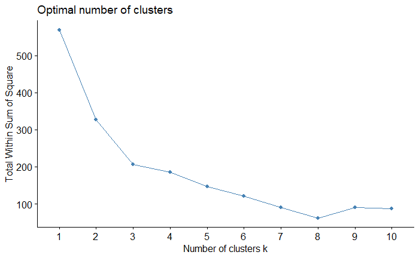

```r
#i.)determining optimal number of clusters
fviz_nbclust(mammals.df[1:8], kmeans, method="wss")
```

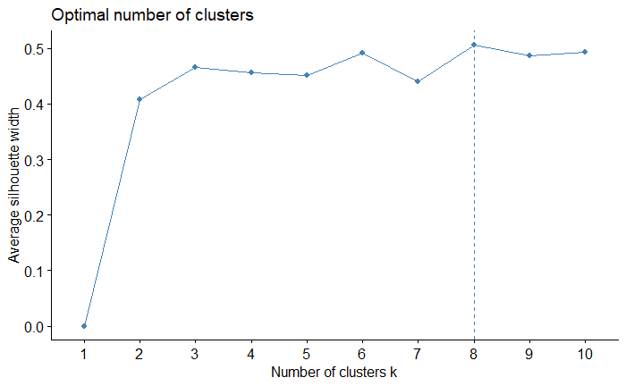

```r
fviz_nbclust(mammals.df[1:8], kmeans, method="silhouette")
```

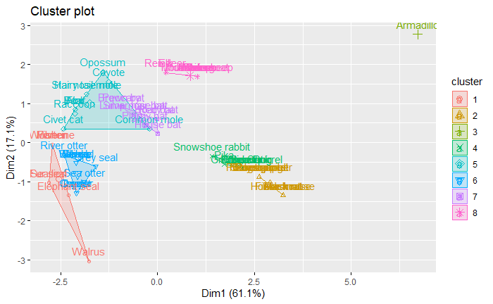

```r
#ii.)using optimal number of clusters
mammals.kmeans <- kmeans(mammals.df[1:8], centers=8, nstart=25)
fviz_cluster(mammals.kmeans, data=mammals.df[1:8])
```

```r
#iii.) how many observations?
cat("Number of Observationssum in cluster 1: ",sum(mammals.kmeans$cluster==1))
```

```
Number of Observationssum in cluster 1:  7
```

```r
cat("Number of Observationssum in cluster 2: ",sum(mammals.kmeans$cluster==2))
```

```
Number of Observationssum in cluster 2:  11
```

```r
cat("Number of Observationssum in cluster 3: ",sum(mammals.kmeans$cluster==3))
```

```
Number of Observationssum in cluster 3:  1
```

```r
cat("Number of Observationssum in cluster 4: ",sum(mammals.kmeans$cluster==4))
```

```
Number of Observationssum in cluster 4:  8
```

```r
cat("Number of Observationssum in cluster 5: ",sum(mammals.kmeans$cluster==5))
```

```
Number of Observationssum in cluster 5:  10
```

```r
cat("Number of Observationssum in cluster 6: ",sum(mammals.kmeans$cluster==6))
```

```
Number of Observationssum in cluster 6:  12
```

```r
cat("Number of Observationssum in cluster 7: ",sum(mammals.kmeans$cluster==7))
```

```
Number of Observationssum in cluster 7:  8
```

```r
cat("Number of Observationssum in cluster 8: ",sum(mammals.kmeans$cluster==8))
```

```
Number of Observationssum in cluster 8:  9
```

```r
#iv.)
cat("Total SSE:",mammals.kmeans$tot.withinss)
```

```
Total SSE: 64.90772
```

```r
#v.)
cat("SSE for each cluster:",mammals.kmeans$withinss)
```

```
SSE for each cluster: 17.71429 5.454545 0 3.875 21.1 8.833333 6.375 1.555556
```

vi.)Analyisis Looking at the clustering and how the mammels fit in a species I can determine that the clustering does make sense and is correct